# 'open-visualizations' for repeated measures in Python - #2

*Jordy van Langen*  
*jordy.vanlangen@sydney.edu.au*  
*19-03-2020*

## Background

This tutorial is a follow up on my ['Open-visualizations tutorial for repeated measures in R'](https://github.com/jorvlan/open-visualizations/tree/master/R) and contributes to a GitHub repository called ['open-visualizations'](https://github.com/jorvlan/open-visualizations).

Next to this notebook, I have also created another tutorial in Python with a slightly different approach which includes R-like behavior with `plotnine`.  
See ['open-visualizations'](https://github.com/jorvlan/open-visualizations) to view that tutorial.

If you have any questions, or suggestions for improvement, please open an issue in the GitHub repository open-visualizations.

If you use my repository for your research, please reference it.

## Load libraries

```python
import numpy as np
import pandas as pd
import seaborn as sns
import matplotlib.pyplot as plt
```

## Activate folder where figures are stored

- By default, figures will not be saved. If you want to save figures, set savefig to `True`.

```python
savefig = False

if savefig:

    #Load libraries
    import os
    from os.path import isdir

    #Get current working directory, but you can specify your own directory of course.
    cwd = os.getcwd()

    if  os.path.exists(cwd + "/repmes_tutorial_2_python/figs"):
        print("Directory already exists")

        #Assign the existing directory to a variable
        fig_dir = cwd + "/repmes_tutorial_2_python/figs"

    elif not os.path.exists(cwd + "/repmes_tutorial_2_python/figs"):
        print("Directory does not exist and will be created ......")
        os.makedirs(cwd + "/repmes_tutorial_2_python/figs")

        if isdir(cwd + "/repmes_tutorial_2_python/figs"):
            print('Directory was created succesfully')

        #Assign the created directory to a variable
        fig_dir = cwd + "/repmes_tutorial_2_python/figs"

    else:
        print("Something went wrong")
```

## Initialize a dataset

```python
# Create a dummy dataset
N=30
np.random.seed(3)
data = np.random.normal(size=(N,))

#Create the dataframe in a wide format with 'Before' and 'After ' as columns
df = pd.DataFrame({'Before': data,
                    'After': data+1})

#Set the amount of jitter and create a dataframe containing the jittered x-axis values
jitter_1 = 0
np.random.seed(3)
df_jitter_1 = pd.DataFrame(np.random.normal(loc=0, scale=jitter_1, size=df.values.shape), columns=df.columns)

#Update the dataframe with adding a number based on the length on the columns. Otherwise all datapoints would be at the same x-axis location.
df_jitter_1 += np.arange(len(df.columns))

#Inspect the created dataframe
pd.options.display.float_format = '{:.3f}'.format
print("The dataframe with 2 variables ")
print(df[['Before', 'After']])
```

```
The dataframe with 2 variables
    Before  After
0    1.789  2.789
1    0.437  1.437
2    0.096  1.096
3   -1.863 -0.863
4   -0.277  0.723
5   -0.355  0.645
6   -0.083  0.917
7   -0.627  0.373
8   -0.044  0.956
9   -0.477  0.523
10  -1.314 -0.314
11   0.885  1.885
12   0.881  1.881
```

[output cut: 17 more lines]

## Figure 1

- In Figure 1, we only display the individual datapoints.

```python
# Define pre-settings
w = 6
h = 6
title_size = 20
xlab_size = 15
ylab_size = 20
labels = ['Before', 'After']
```

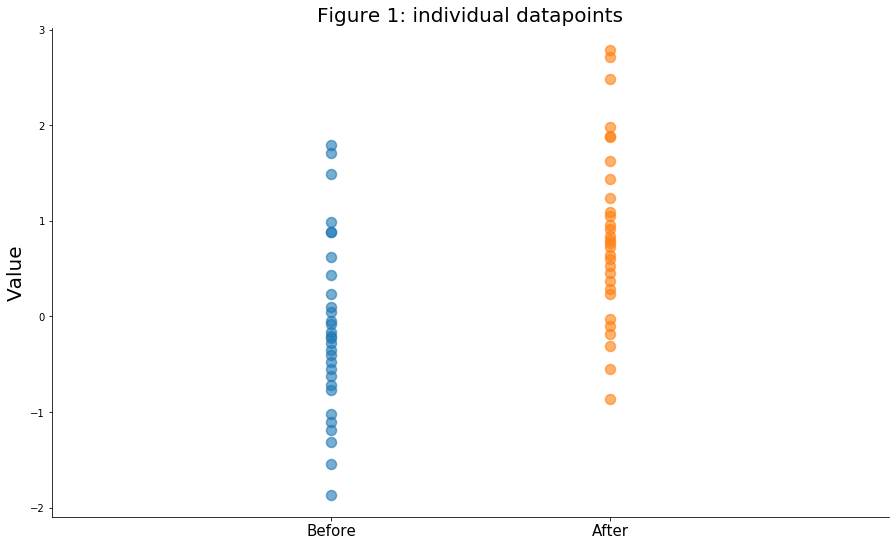

```python
# Create empty figure and plot the individual datapoints
fig, ax = plt.subplots(figsize=(15,9))

for col in df:
    ax.plot(df_jitter_1[col], df[col], 'o', alpha=.6, zorder=2, ms=10, mew=1.5)

    #Additional settings
    ax.set_xticks(range(len(df.columns)))
    ax.set_xticklabels((labels), size= xlab_size)
    ax.set_xlim(-1, len(df.columns))
    ax.set_ylabel('Value', size = ylab_size)
    ax.set_title('Figure 1: individual datapoints', size = title_size)
    sns.despine()

if savefig:
    plt.savefig(fig_dir + "/figure1.png", width = w, height = h)
```

## Figure 2

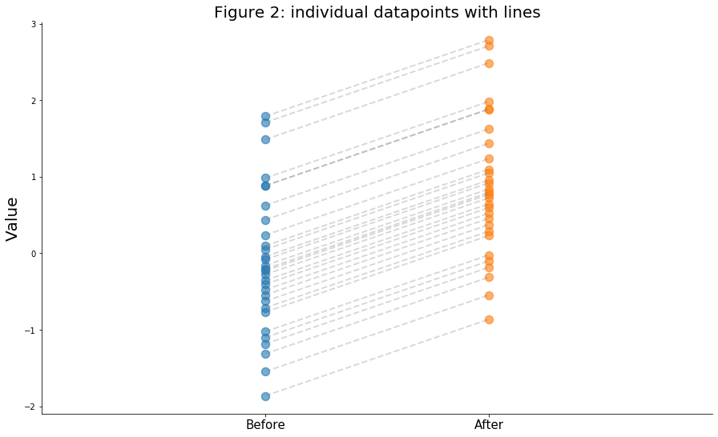

```python
# Create empty figure and plot the individual datapoints
fig, ax = plt.subplots(figsize=(15,9))

for col in df:
    ax.plot(df_jitter_1[col], df[col], 'o', alpha=.6, zorder=2, ms=10, mew=1.5)

for idx in df.index:
    ax.plot(df_jitter_1.loc[idx,['Before','After']], df.loc[idx,['Before','After']], color = 'gray', linewidth = 2, linestyle = '--',alpha = .3)

    #Additonal settings
    ax.set_xticks(range(len(df.columns)))
    ax.set_xticklabels((labels), size= xlab_size)
    ax.set_xlim(-1, len(df.columns))
    ax.set_ylabel('Value', size = ylab_size)
    ax.set_title('Figure 2: individual datapoints with lines', size = title_size)
    sns.despine()

if savefig:
    plt.savefig(fig_dir + "/figure2.png", width = w, height = h)
```

## Figure 3

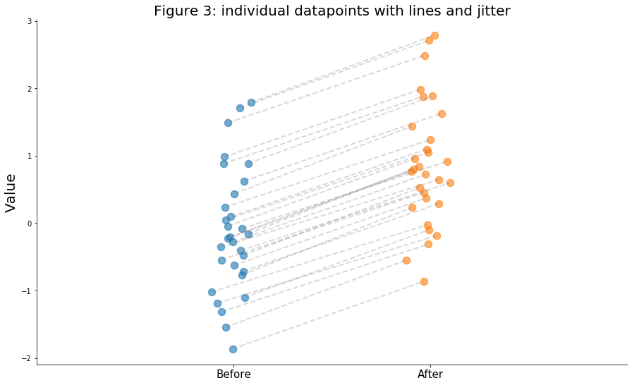

```python
#Set the amount of jitter and create a dataframe containing the jittered x-axis values
jitter_2 = 0.05
np.random.seed(3)
df_jitter_2 = pd.DataFrame(np.random.normal(loc=0, scale=jitter_2, size=df.values.shape), columns=df.columns)

#Update the dataframe with adding a number based on the length on the columns. Otherwise all datapoints would be at the same x-axis location.
df_jitter_2 += np.arange(len(df.columns))

# Create empty figure and plot the individual datapoints
fig, ax = plt.subplots(figsize=(15,9))

for col in df:
    ax.plot(df_jitter_2[col], df[col], 'o', alpha=.6, zorder=2, ms=10, mew=1.5)

for idx in df.index:
    ax.plot(df_jitter_2.loc[idx,['Before','After']], df.loc[idx,['Before','After']], color = 'gray', linewidth = 2, linestyle = '--',alpha = .3)

    #Additonal settings
    ax.set_xticks(range(len(df.columns)))
    ax.set_xticklabels((labels), size= xlab_size)
    ax.set_xlim(-1, len(df.columns))
    ax.set_ylabel('Value', size = ylab_size)
    ax.set_title('Figure 3: individual datapoints with lines and jitter', size = title_size)
    sns.despine()

if savefig:
    plt.savefig(fig_dir + "/figure3.png", width = w, height = h)
```

## Figure 4

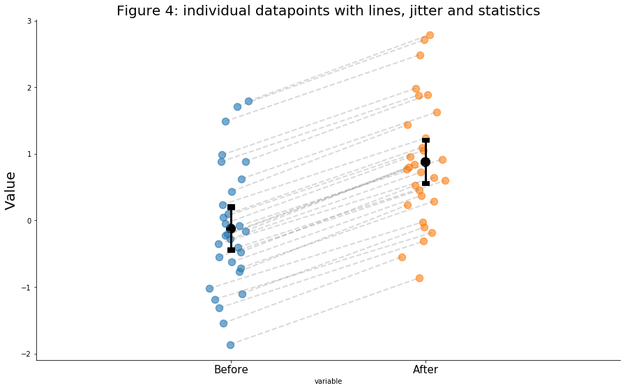

```python
#Merge dataframe from wide to long for sns.pointplot
df_long = pd.melt(df,  value_vars=['Before','After'])

# Create empty figure and plot the individual datapoints
fig, ax = plt.subplots(figsize=(15,9))

for col in df:
    ax.plot(df_jitter_2[col], df[col], 'o', alpha=.6, zorder=2, ms=10, mew=1.5)

for idx in df.index:
    ax.plot(df_jitter_2.loc[idx,['Before','After']], df.loc[idx,['Before','After']], color = 'gray', linewidth = 2, linestyle = '--',alpha = .3)
    sns.pointplot(x='variable', y='value', ci=95, data=df_long, join=False, scale=1.5, color = 'black', capsize = .03) #palette = 'Paired'


#Additonal settings
    ax.set_xticks(range(len(df.columns)))
    ax.set_xticklabels((labels), size= xlab_size)
    ax.set_xlim(-1, len(df.columns))
    ax.set_ylabel('Value', size = ylab_size)
    ax.set_title('Figure 4: individual datapoints with lines, jitter and statistics', size = title_size)
    sns.despine()


if savefig:
    plt.savefig(fig_dir + "/figure4.png", width = w, height = h)
```

## Figure 5

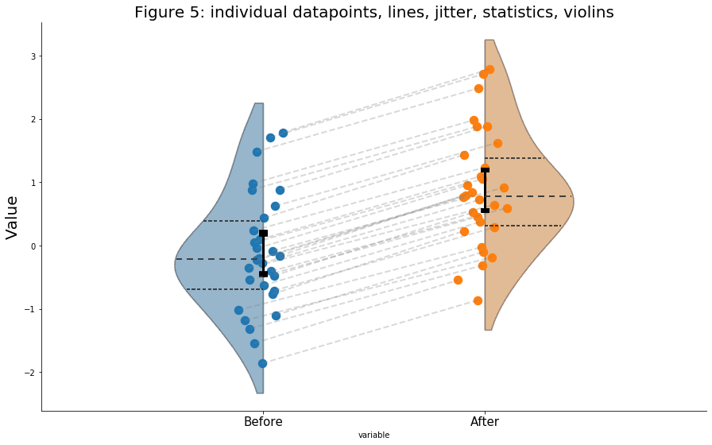

```python
# Create empty figure and plot the individual datapoints
fig, ax = plt.subplots(figsize=(15,9))

for col in df:
    ax.plot(df_jitter_2[col], df[col], 'o', alpha=1, zorder=2, ms=10, mew=1.5)

for idx in df.index:
    ax.plot(df_jitter_2.loc[idx,['Before','After']], df.loc[idx,['Before','After']], color = 'gray', linewidth = 2, linestyle = '--',alpha = .3)
    sns.pointplot(x='variable', y='value', ci=95, data=df_long, join=False, scale=0.01, color = 'black', capsize = .03)
    sns.violinplot(x='variable', y='value', data=df_long, hue = 'variable', split = True, inner = 'quartile', cut=1)


#Additonal settings
    ax.set_xticks(range(len(df.columns)))
    ax.set_xticklabels((labels), size= xlab_size)
    ax.set_xlim(-1, len(df.columns))
    ax.set_ylabel('Value', size = ylab_size)
    ax.set_title('Figure 5: individual datapoints, lines, jitter, statistics, violins', size = title_size)
    ax.legend_.remove()
    sns.despine()
    plt.setp(ax.collections, alpha=.02)


if savefig:
    plt.savefig(fig_dir + "/figure5.png", width = w, height = h)
```

## Figure 6

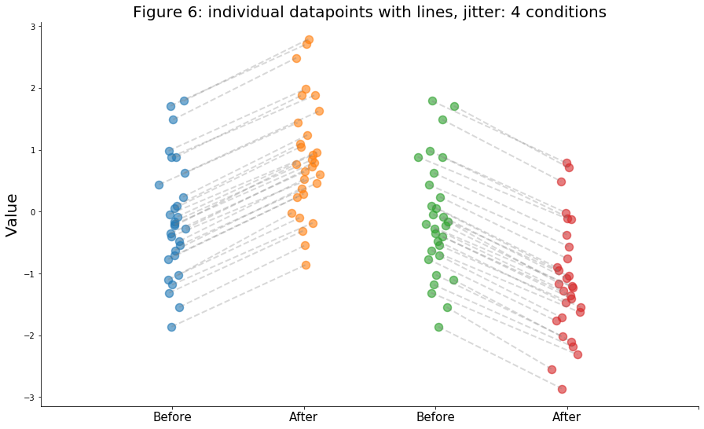

```python
#Create a dataframe do display 4 conditions
df_2 = pd.DataFrame({'Before': data,
                    'After': data+1,
                  'Before1': data,
                  'After1': data-1})

df_jitter_3 = pd.DataFrame(np.random.normal(loc=0, scale=jitter_2, size=df_2.values.shape), columns=df_2.columns)
df_jitter_3

#Do an additional step to create a jittered values for the 4 columns.. i.e., jitter values around condition 1 and 2 + jitter values for condition 3 and 4.
df_jitter_3 += np.arange(len(df_2.columns))
df_jitter_3

# Create empty figure and plot the individual datapoints
fig, ax = plt.subplots(figsize=(15,9))

for col in df_2:
    ax.plot(df_jitter_3[col], df_2[col], 'o', alpha=.6, zorder=2, ms=10, mew=1.5)

for idx in df_2.index:
    ax.plot(df_jitter_3.loc[idx,['Before','After']], df_2.loc[idx,['Before','After']], color = 'gray', linewidth = 2, linestyle = '--',alpha = .3)
    ax.plot(df_jitter_3.loc[idx,['Before1','After1']], df_2.loc[idx,['Before1','After1']], color = 'gray', linewidth = 2, linestyle = '--', alpha =.3)

    #Additonal settings
    ax.set_xticks(range(len(df.columns)))
    ax.set_xticklabels((['Before', 'After', 'Before', 'After']), size= xlab_size)
    ax.set_xlim(-1, len(df.columns))
    ax.set_ylabel('Value', size = ylab_size)
    ax.set_title('Figure 6: individual datapoints with lines, jitter: 4 conditions', size = title_size)
    sns.despine()
    plt.setp(ax.collections, alpha=.02)
    plt.setp(ax, xticks=[0, 1, 2, 3, 4])


if savefig:
    plt.savefig(fig_dir + "/figure6.png", width = w, height = h)
```

## Figure 7

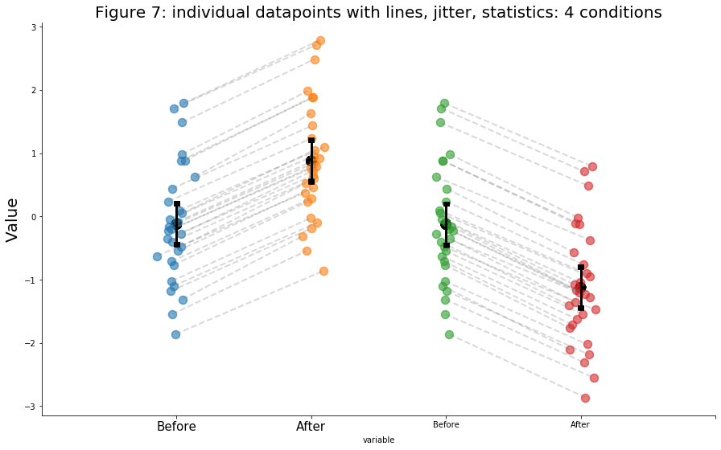

```python
#Merge dataframe from wide to long for sns.pointplot
df_long_2 = pd.melt(df_2,  value_vars=['Before','After', 'Before1', 'After1'])

# Create empty figure and plot the individual datapoints
fig, ax = plt.subplots(figsize=(15,9))

for col in df_2:
    ax.plot(df_jitter_3[col], df_2[col], 'o', alpha=.6, zorder=2, ms=10, mew=1.5)

for idx in df_2.index:
    ax.plot(df_jitter_3.loc[idx,['Before','After']], df_2.loc[idx,['Before','After']], color = 'gray', linewidth = 2, linestyle = '--',alpha = .3)
    ax.plot(df_jitter_3.loc[idx,['Before1','After1']], df_2.loc[idx,['Before1','After1']], color = 'gray', linewidth = 2, linestyle = '--', alpha = .3)
    sns.pointplot(x='variable', y='value', ci=95, data=df_long_2, join=False, scale=1.5, color = 'black', capsize = .03)


    #Additonal settings
    ax.set_xticks(range(len(df.columns)))
    ax.set_xticklabels((['Before', 'After', 'Before', 'After']), size= xlab_size)
    ax.set_xlim(-1, len(df.columns))
    ax.set_ylabel('Value', size = ylab_size)
    ax.set_title('Figure 7: individual datapoints with lines, jitter, statistics: 4 conditions', size = title_size)
    sns.despine()
    plt.setp(ax, xticks=[0, 1, 2, 3, 4])


if savefig:
    plt.savefig(fig_dir + "/figure7.png", width = w, height = h)
```

## Figure 8

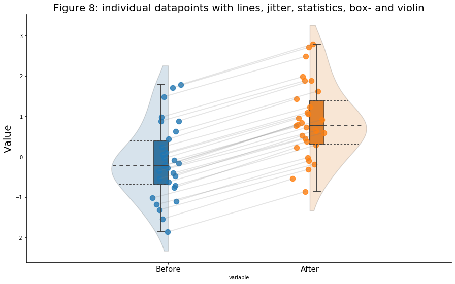

```python
# Create empty figure and plot the individual datapoints
fig, ax = plt.subplots(figsize=(15,9))

for col in df:
    ax.plot(df_jitter_2[col], df[col], 'o', alpha=.8, zorder=2, ms=10, mew=1.5)

for idx in df.index:
    ax.plot(df_jitter_2.loc[idx,['Before','After']], df.loc[idx,['Before','After']], color = 'gray', linewidth = 2, linestyle = '-',alpha = .2)

for value in df_long_2:
    sns.violinplot(x='variable', y='value', data=df_long, hue = 'variable', split = True, inner = 'quartile', cut=1, dodge = True)
    sns.boxplot(x='variable', y='value', data=df_long, hue = 'variable', dodge = True, width = 0.2, fliersize = 2)

    #Additonal settings
    ax.set_xticks(range(len(df.columns)))
    ax.set_xticklabels((['Before', 'After']), size= xlab_size)
    ax.set_xlim(-1, len(df.columns))
    ax.set_ylabel('Value', size = ylab_size)
    ax.set_title('Figure 8: individual datapoints with lines, jitter, statistics, box- and violin', size = title_size)
    sns.despine()
    ax.legend_.remove()
    plt.setp(ax.collections, alpha=.1)


if savefig:
    plt.savefig(fig_dir + "/figure8.png", width = w, height = h)
```

## General remarks / tips

- If you want to save your figures in a high-quality manner for e.g., publications, you could save your figure with a `.tif` extension and add `dpi=` as used in the following line of code:

  `plt.savefig("/figure.tif", width = w, height = h, dpi = 600)`

## That's it! (for now)

You have reached the end of this document.

I hope you'll be able to use this tutorial to create more `open-visualizations` for your research!

open-visualizations for repeated measures in `R` and `Python` by [**Jordy van Langen**](https://jordyvanlangen.com)